# Effectiveness of advertisements on me

## Which platform has a more effective marketing strategy?

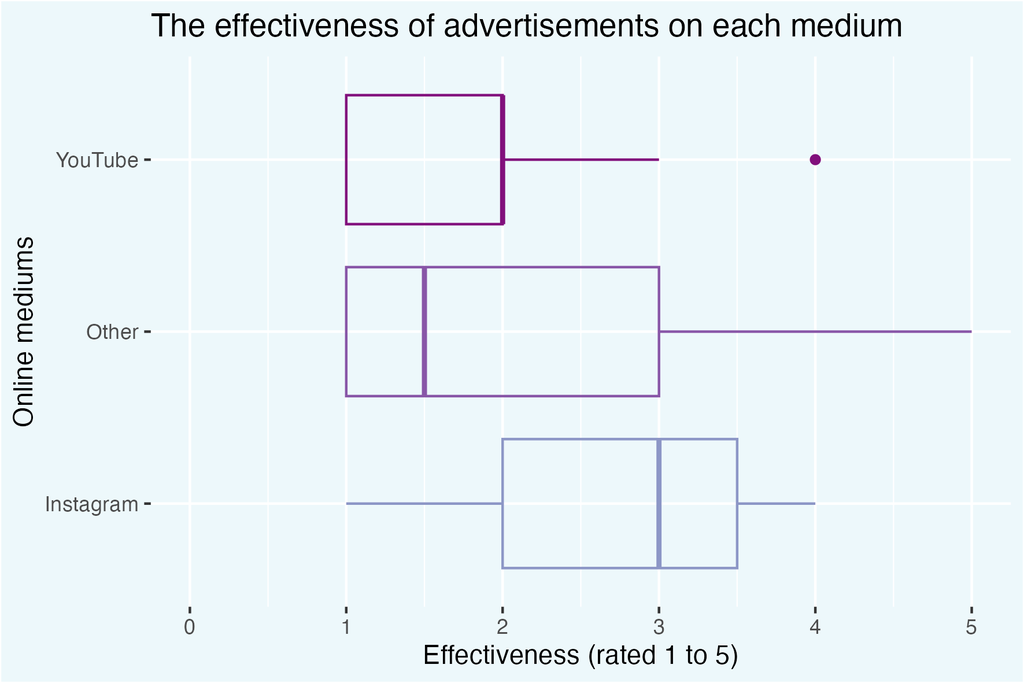

plot3

This plot displays the effectiveness of advertisements displayed on on different online mediums. The effectiveness variable is derived from received feedback of the user. We ask the user how likely they were going to purchase the recommended product/service or visit the recommended location due to the advertisement. The user rates from 1 being not probable at all, to 5 being very likely.

From the plot we observe Instagram has the highest mean for effectiveness, followed by Youtube and then other online mediums. We can say that Instagram on average has the highest effectiveness of the 3 recorded platforms. My next focus is to look at what category of advertisements has the highest prevalence, and whether that category is also prevalent in comparison to other advertisement categories.

From the ad_category variable we look for the category with highest number of appearances over all online mediums, which is “Application/Websites” in this instance. From this information I formulated another plot that displays the relationship between website/application advertisements and non-website/application advertisements.

## The most popular advertisement category vs most effective online advertisement platform

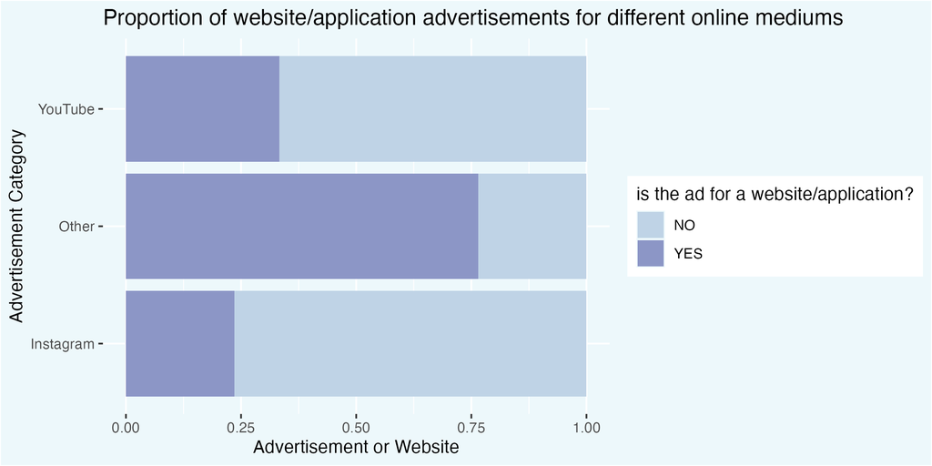

plot2

From our previous graph we have concluded that Instagram is the more effective online advertising platform under comparison. However the website/application only covers a little under 25% of the advertisement categories though it the most prevalent advertisement category. This is very different from ‘other’ which was the least effective online advertising platform under comparison. So it shows that the most prevalent ad_category possibly didn’t actually affect the effectiveness.

## Early or Late Online User?

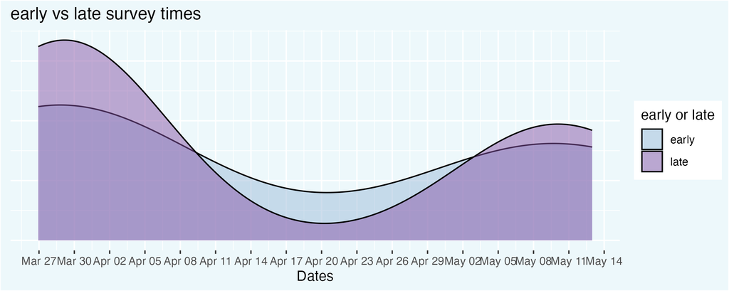

plot1

For my last graph I wanted to observe some time patterns of when the survey was conducted. As the survey audience was me, and I only submitted survey responses admist or after my online time, the timestamps are a good representation of when my online hours are.

From the graph, I observe that other than dates between approximately 9th April and 2nd of May my recorded times are more of late than early hours. It so happens that my last recorded response for Project 2 was on the 30th March and first recorded response date for Project 4 was on the 7th May which somewhat overlaps with the the aforementioned interval. It seems that that the empty interval was recorded on the graph too, however looking at the data it seems that I am a frequent late night online user.